# Part II - Features that Affect Borrower's Annual Percentage Rate

## by Fidelis Katandika

## Investigation Overview

This exploration focused on the borrowers in the dataset that had loans with prosper in the dataset, which came to around 19000+ records. The exploration focused on identifying what features affected Borrower's Annual Percentage Rate. The results of the exploration have shown a strong correlation with between Borrower Annual Percentage Rate, Prosper Rating and Credit Score. Additionally, the loan term revealed loans with a length of 12 months are cheaper, followed by 60 month-long loans. 12 month loans overode the credit score rating. 36 month loans were on average more costly than the other 2 categories. The Credit Score/Prosper Rating influence the BAPR for loans with length large than 12 months, however, the loans with the longest term have better Borrower Average with significant influence from the credit score.

## Dataset Overview

The data consists 113,937 loans from prosper with 81 variables on each loan. The subset of the dataset which has 19771 observations and 11 attributes was used for the analysis.

## Borrower's Annual Percentage Rate

The Borrower's APR is the annual interest rate charged on a loan. The graph depicts peak Borrower's APR lies between 12% to around 30%. The distribution is unimodal. There is a small number of borrowers with APR that is greater than 40%.

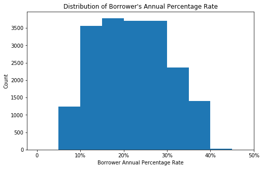

### Credit Score Average

The credit score appears is unimodal in distribution. The vast majority of borrowers lie in a particular range 680 to 730, with the extreme ends having fewer numbers.

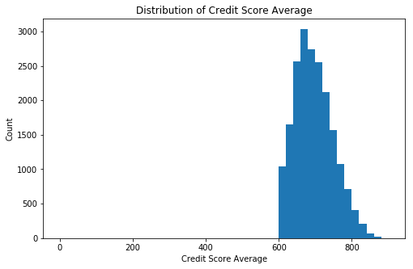

## Prosper Rating by Average Credit Score

A Box Plot show Credit Score Avg and Prosper Rating largely behaving the same way. These variable affect BAPR in a very similar mannner.

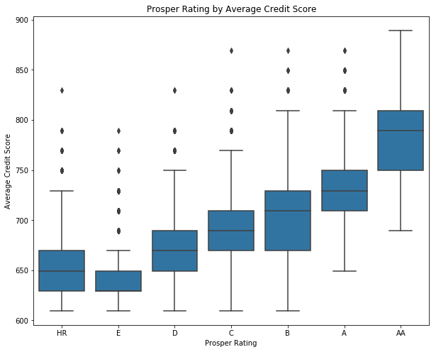

## Loan Term by Borrower's APR

Loans with a duration of 36 months have the highest average BAPR, followed by the 60 month-long loan. The 12 month loan has the lower average BAPR

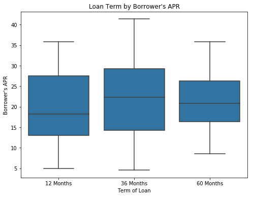

## CreditScoreAvg by BorrowerAPR

A scatter plot of CreditScoreAvg and BorrowerAPR, shows there is negative correlation between the attributes. The better score the more likely the BAPR will be lower.

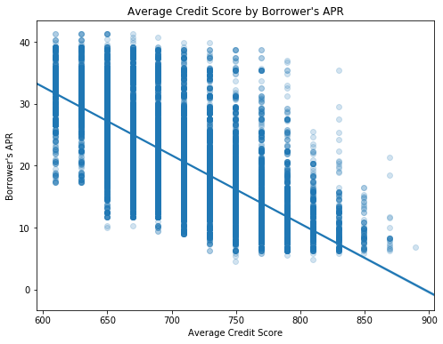

## Average Credit Score by Borrower's APR

The graph provides valueable data, its shows 12 Months-long loan largely have low BAPR and are not affected by the score as much as the other loan terms. On average 36 months loan are more costly, but has cheaper and more costly extermes over the Credit Score range. The Score affect 60 months loan, the better the score the lower the cost of borrowing but on average is it the better choice.

The Credit Score/Prosper Rating influence the BAPR for loans with length large than 12 months, however, the loans with the longest term have better Borrower Average with significant influence from the credit score.

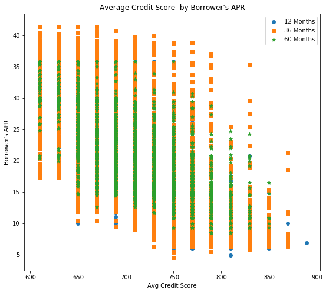